# Lectura y preparación de datos para Data Mining

# 7 Clasificación de jugadores

## 7.1 Añadir una columna al conjunto de datos denominada “Altura” que contenga los valores: {“bajo”, “normal”, “alto”}. La asignación del valor depende de la altura de cada jugador. Se asigna:

- bajo: los 50 jugadores más bajos
- alto: los 50 jugadores más altos
- normal: el resto de jugadores

```r
Players['Altura']= 'normal'
Players <- Players[order(Players$Height,decreasing=TRUE),]
Players[1:50,'Altura'] = 'alto'
Players <- Players[order(Players$Height,decreasing=FALSE),]
Players[1:50,'Altura'] = 'bajo'

table(Players$Altura)
```

```
##
##   alto   bajo normal
##     50     50    198
```

## 7.2 Añadir una columna al conjunto de datos denominada “Peso” que contenga los valores: {“bajo”, “normal”, “alto”}. La asignación del valor depende del peso de cada jugador. Se asigna:

- bajo: los 50 jugadores con menor peso
- alto: los 50 jugadores con mayor peso
- normal: el resto de jugadores

```r
Players['Peso']= 'normal'
Players <- Players[order(Players$Weight,decreasing=TRUE),]
Players[1:50,'Peso'] = 'alto'
Players <- Players[order(Players$Weight,decreasing=FALSE),]
Players[1:50,'Peso'] = 'bajo'

table(Players$Peso)
```

```
##
##   alto   bajo normal
##     50     50    198
```

```r
PlayersStats <- Players %>% select(Peso,Weight)
PlayersStats <- PlayersStats %>%group_by(Peso)  %>% summarise(media = round(mean(Weight),2), std=round(sd(Weight),2))
print(PlayersStats)
```

```
## # A tibble: 3 x 3
##   Peso   media   std
##   <chr>  <dbl> <dbl>
## 1 alto    264.  16.3
## 2 bajo    179.   8.2
## 3 normal  219.  17.4
```

```r
rm(PlayersStats)
```

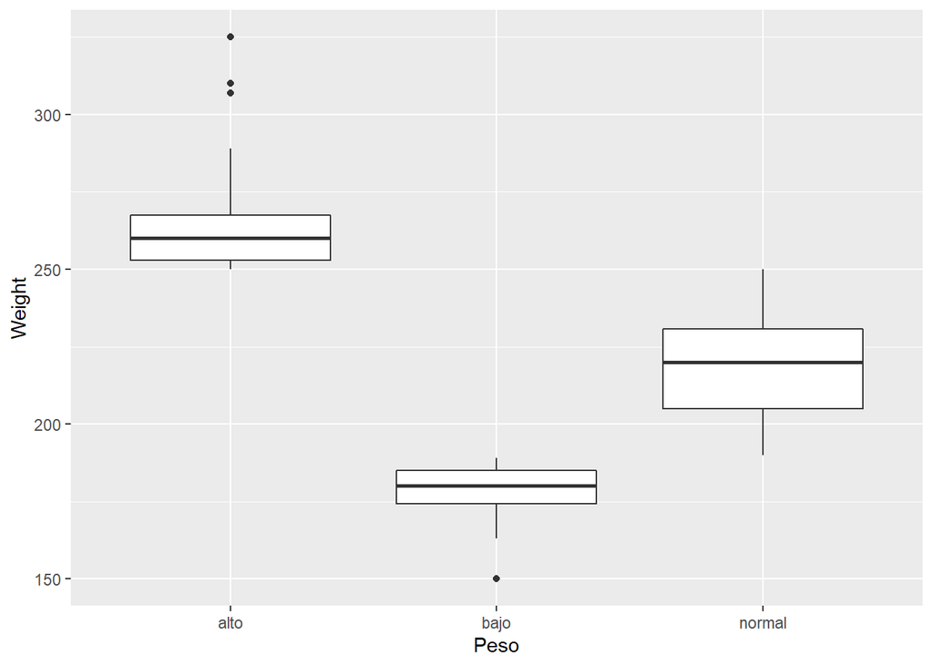

```r
Players$Altura <- factor(Players$Altura,
                          levels= c("bajo","normal","alto"),
                          ordered = TRUE
                          )

ggplot(Players,aes(y=Weight,x=Peso)) +geom_boxplot()
```

```r
str(Players$Altura)
```

```
##  Ord.factor w/ 3 levels "bajo"<"normal"<..: 1 1 1 1 1 1 1 1 1 1 ...
```

```r
AltNormalPesoAltoAlfa <- filter(Players,Peso=='normal'&Altura =='alto')
AltNormalPesoAltoAlfa[order(AltNormalPesoAltoAlfa$Player,decreasing=FALSE),]
```

```
##                   Player Draft.Year Height Position Weight Altura   Peso
## 19        Brad Daugherty       1986    212    Guard    245   alto normal
## 11            Chris Bosh       2003    210    Guard    235   alto normal
## 20         Dirk Nowitzki       1998    212    Guard    245   alto normal
## 3  Giannis Antetokounmpo       2013    211    Guard    222   alto normal
## 2       Hot Rod Williams       1985    210    Guard    215   alto normal
## 5             Jack Sikma       1977    210    Guard    230   alto normal
## 10       Jermaine O'Neal       1996    210    Guard    235   alto normal
## 22           Joel Embiid       2014    213    Guard    249   alto normal
## 4    Kareem Abdul-Jabbar       1969    217    Guard    225   alto normal
## 16    Karl-Anthony Towns       2015    212    Guard    244   alto normal
## 17    Karl-Anthony Towns       2015    213    Guard    244   alto normal
## 12         Kevin Garnett       1995    210    Guard    240   alto normal
## 18          Kevin Willis       1984    212    Guard    245   alto normal
## 15    Kristaps Porzingis       2015    221    Guard    240   alto normal
## 13          Marcus Camby       1996    210    Guard    240   alto normal
## 21           Mehmet Okur       2001    210    Guard    249   alto normal
## 14         Patrick Ewing       1985    212    Guard    240   alto normal
## 8        Rasheed Wallace       1995    210    Guard    230   alto normal
## 23             Rik Smits       1988    223    Guard    250   alto normal
## 9          Robert Parish       1976    212    Guard    230   alto normal
## 7           Rony Seikaly       1988    210    Guard    230   alto normal
## 6            Roy Tarpley       1986    210    Guard    230   alto normal
## 1           Tom McMillen       1974    210    Guard    215   alto normal
```

```r
print(AltNormalPesoAltoAlfa)
```

```
##                   Player Draft.Year Height Position Weight Altura   Peso
## 1           Tom McMillen       1974    210    Guard    215   alto normal
## 2       Hot Rod Williams       1985    210    Guard    215   alto normal
## 3  Giannis Antetokounmpo       2013    211    Guard    222   alto normal
## 4    Kareem Abdul-Jabbar       1969    217    Guard    225   alto normal
## 5             Jack Sikma       1977    210    Guard    230   alto normal
## 6            Roy Tarpley       1986    210    Guard    230   alto normal
## 7           Rony Seikaly       1988    210    Guard    230   alto normal
## 8        Rasheed Wallace       1995    210    Guard    230   alto normal
## 9          Robert Parish       1976    212    Guard    230   alto normal
## 10       Jermaine O'Neal       1996    210    Guard    235   alto normal
## 11            Chris Bosh       2003    210    Guard    235   alto normal
## 12         Kevin Garnett       1995    210    Guard    240   alto normal
## 13          Marcus Camby       1996    210    Guard    240   alto normal
## 14         Patrick Ewing       1985    212    Guard    240   alto normal
## 15    Kristaps Porzingis       2015    221    Guard    240   alto normal
## 16    Karl-Anthony Towns       2015    212    Guard    244   alto normal
## 17    Karl-Anthony Towns       2015    213    Guard    244   alto normal
## 18          Kevin Willis       1984    212    Guard    245   alto normal
## 19        Brad Daugherty       1986    212    Guard    245   alto normal
## 20         Dirk Nowitzki       1998    212    Guard    245   alto normal
## 21           Mehmet Okur       2001    210    Guard    249   alto normal
## 22           Joel Embiid       2014    213    Guard    249   alto normal
## 23             Rik Smits       1988    223    Guard    250   alto normal
```

```r
rm(AltNormalPesoAltoAlfa)
```

## 3.4 Transformar las variables Height, Player, Position, Season, Team y Weight en variables categóricas.

```r
Vartofact <- c('Height' , 'Player' , 'Position' , 'Season' , 'Team' , 'Weight')

for (x in Vartofact){
nba[,x] <- as.factor(nba[,x])
str(nba[,x])
                    }
```

```
##  Factor w/ 33 levels "175","177","180",..: 20 9 16 9 16 13 26 9 11 26 ...
##  Factor w/ 274 levels "Aaron McKie",..: 208 233 129 244 66 117 103 58 134 141 ...
##  Factor w/ 1 level "Guard": 1 1 1 1 1 1 1 1 1 1 ...
##  Factor w/ 34 levels "1984-1985","1985-1986",..: 33 33 33 33 33 33 33 33 33 33 ...
##  Factor w/ 35 levels "Atlanta Hawks",..: 13 24 6 11 32 12 17 28 35 19 ...
##  Factor w/ 76 levels "150","163","165",..: 36 25 45 16 36 36 65 20 29 51 ...
```

```r
rm(Vartofact )
```